# Predictors NY

### Range geometry

```r
# Functions:
## Normalized circularity function (written by ANONYMIZED-3)
circNorm <- function(x){
    perimeter <- perim(x)
    area <- expanse(x)
    res <- (perimeter^2) / (4 * pi * area)
    return(res)
}

## Smallest distance from the range centroid to the atlas border
minDist <- function(centroid, borders){
  res <- min(
    distance(
      crds(centroid),
      crds(borders),
      lonlat = F)
    )
  return(res)
}

# s2 settings:
sf_use_s2(FALSE) # we use planar projections (i.e., in metres) so this can be turned off
```

```
Spherical geometry (s2) switched off
```

```r
#----------------------------------------------------------#
# Load data -----
#----------------------------------------------------------#

data_sf <-
  readRDS(data_sf_path) %>%
  filter(scalingID == 1 &
           cells_keep == 1)

#----------------------------------------------------------#
# Atlas geometries  -----
#----------------------------------------------------------#

sf_current_atlas <-
  data_sf %>%
  filter(samplingPeriodID == 1) %>%
  select(geometry) %>%
  st_as_sf() %>%
  summarise(geometry = st_union(geometry), .groups = "drop") %>%
  st_transform(crs = unique(data_sf$verbatimFootprintSRS)) %>%
  st_make_valid()
```

```
although coordinates are longitude/latitude, st_union assumes that they are
planar
```

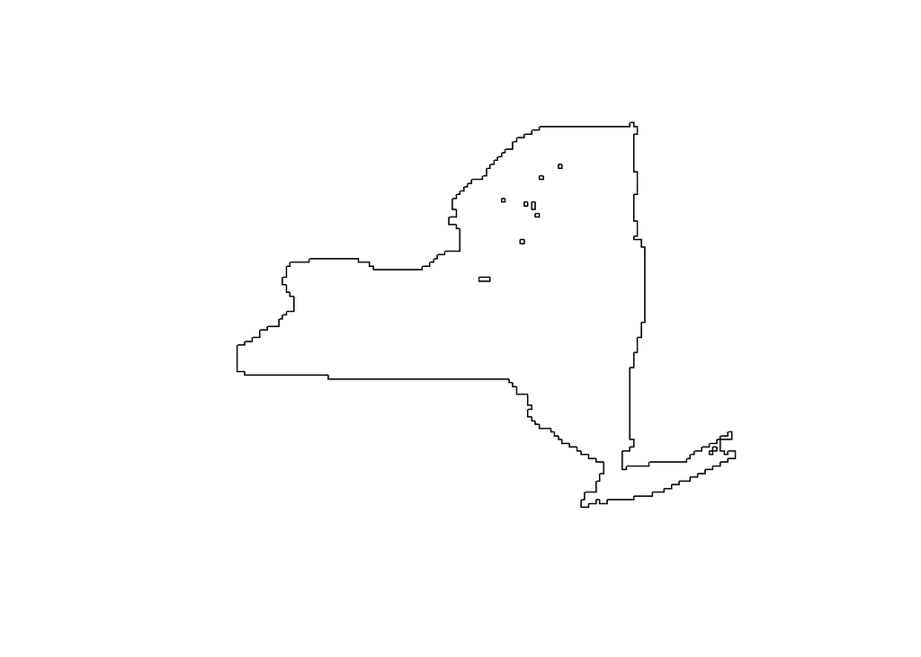

```r
plot(sf_current_atlas)
```

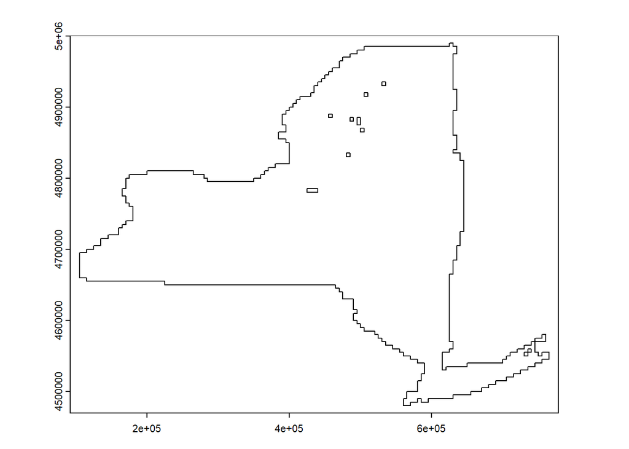

```r
# vectorize atlas
terra_current_atlas <- vect(sf_current_atlas)

plot(terra_current_atlas)
```

```r
# Store borders as lines
atlas_border_lines <- terra::as.lines(terra_current_atlas)

#----------------------------------------------------------#
# Single species range geometries  -----
#----------------------------------------------------------#

grouped_list <-
  data_sf %>%
  group_by(samplingPeriodID, verbatimIdentification) %>%
  filter(species_keep == 1) %>%
  group_split()

tictoc::tic()
range_geometries <- map_dfr(grouped_list, function(dta) {

  sp_range <-
    dta %>%
      dplyr::select(geometry, siteID, datasetID) %>%
      st_transform(crs = st_crs(atlas_border_lines)) %>%
      summarise() %>%
      terra::vect()

  sp_range_centroid <-
    centroids(sp_range)

  # checks
  # plot(sp_range); plot(sp_range_centroid, add = T, col = "red")

  # Compute range attributes
  tibble(
    datasetID = unique(dta$datasetID),
    samplingPeriodID = unique(dta$samplingPeriodID),
    verbatimIdentification = unique(dta$verbatimIdentification),
    circNorm = circNorm(sp_range),
    minDist_toBorder_centr = minDist(sp_range_centroid, atlas_border_lines)
    )

})
tictoc::toc() # 108.94 sec elapsed
```

```
67.68 sec elapsed
```

```r
# checks:
range_geometries %>%
  skimr::skim()
```

Data summary

| Name | Piped data |
| --- | --- |
| Number of rows | 466 |
| Number of columns | 5 |
| _______________________ |  |
| Column type frequency: |  |
| character | 1 |
| numeric | 4 |
| ________________________ |  |
| Group variables | None |

**Variable type: character**

| skim_variable | n_missing | complete_rate | min | max | empty | n_unique | whitespace |
| --- | --- | --- | --- | --- | --- | --- | --- |
| verbatimIdentification | 0 | 1 | 9 | 32 | 0 | 233 | 0 |

**Variable type: numeric**

| skim_variable | n_missing | complete_rate | mean | sd | p0 | p25 | p50 | p75 | p100 | hist |
| --- | --- | --- | --- | --- | --- | --- | --- | --- | --- | --- |
| datasetID | 0 | 1 | 6.00 | 0.00 | 6.00 | 6.00 | 6.00 | 6.00 | 6.00 | ▁▁▇▁▁ |
| samplingPeriodID | 0 | 1 | 1.50 | 0.50 | 1.00 | 1.00 | 1.50 | 2.00 | 2.00 | ▇▁▁▁▇ |
| circNorm | 0 | 1 | 172.32 | 173.49 | 1.27 | 30.19 | 116.39 | 269.71 | 769.29 | ▇▂▂▁▁ |
| minDist_toBorder_centr | 0 | 1 | 34788.29 | 17516.27 | 1152.08 | 24545.67 | 35029.02 | 44744.41 | 93733.18 | ▅▇▆▂▁ |

```r
rm(list = setdiff(ls(),c("data_sf_path","tax_path","sp_data_path","sci_name","traits_merged", "pd", "IUCN_df", "range_geometries")))
```

### Spatial autocorrelation

We calculate the difference in expected and observed join counts for presences across the atlas for each species and sampling period. This is done using the `joincount.test()` function from the `spdep` package. The join count test is a measure of spatial autocorrelation that counts the number of pairs of neighboring sites that have the same value (in this case, presence or absence of a species). In the calculation of delat join count, we follow work by Soria et al. (2025) [5]

```r
# CRS
ny_crs <-"epsg:32118"  #verbatimFootprintSRS (NAD83 / New York Long Island)

# Read data
data_sf <-
  readRDS(data_sf_path) %>%
  filter(scalingID == 1 &
           cells_keep == 1 &
           species_keep == 1) %>%
  st_transform(crs = ny_crs)


# calculate join count across samplingPeriods for each species
sampling_periods <- c(1,2)

# Safe versions of spatial autocorrelation functions
safe_joincount_test <- possibly(function(x, nb) joincount.test(as.factor(x), nb2listw(nb, style = "B", zero.policy = TRUE)), otherwise = NA)

tictoc::tic()
joincount_df <- map_dfr(sampling_periods, function(sampling_period){
  tp_subset <-
    data_sf %>%
    filter(samplingPeriodID == sampling_period)

  sp_names <-
    tp_subset %>%
    st_drop_geometry() %>%
    distinct(verbatimIdentification) %>%
    pull()

  all_sites <-
    data_sf %>%
    select(siteID, geometry) %>%
    unique()

  map_dfr(sp_names, function(sp_name){

    sp_data <-
      tp_subset %>%
      st_drop_geometry() %>%
      filter(verbatimIdentification == sp_name) %>%
      full_join(all_sites, by = "siteID") %>%
      mutate(
        presence = if_else(is.na(verbatimIdentification), 0, 1),
        verbatimIdentification = sp_name) %>%
      st_as_sf()

    # checks:
    # plot(sp_data["presence"])

    # Count the number of presences
    num_pres <- sum(sp_data$presence, na.rm = TRUE)

    # Creating neighbors (queen)
    nb_q <- spdep::poly2nb(sp_data, queen = TRUE)

    # Join count test
    jc_res_q <- safe_joincount_test(sp_data$presence, nb_q)

    # Save results in a dataframe
    tibble(
      samplingPeriodID = sampling_period,
      verbatimIdentification = sp_name,
      presence_n = num_pres,
      joincount_statistic = ifelse(is.na(jc_res_q), NA,
                                   jc_res_q[[2]]$estimate[1])[[1]],
      joincount_expectation = ifelse(is.na(jc_res_q), NA,
                                     jc_res_q[[2]]$estimate[2])[[1]],
      joincount_p_val = ifelse(is.na(jc_res_q), NA,
                               jc_res_q[[2]]$p.value)[[1]],
      joincount_delta = ifelse(is.na(jc_res_q), NA,
                               ((jc_res_q[[2]]$estimate[1] /
                                   num_pres) -
                                  (jc_res_q[[2]]$estimate[2] /
                                     num_pres)))[[1]]
      ) %>%
      unique()


  })

})

tictoc::toc() # 1376.94 sec elapsed
```

```
672.47 sec elapsed
```

```r
# checks:
joincount_df %>%
  skimr::skim()
```

Data summary

| Name | Piped data |
| --- | --- |
| Number of rows | 466 |
| Number of columns | 7 |
| _______________________ |  |
| Column type frequency: |  |
| character | 1 |
| numeric | 6 |
| ________________________ |  |
| Group variables | None |

**Variable type: character**

| skim_variable | n_missing | complete_rate | min | max | empty | n_unique | whitespace |
| --- | --- | --- | --- | --- | --- | --- | --- |
| verbatimIdentification | 0 | 1 | 9 | 32 | 0 | 233 | 0 |

**Variable type: numeric**

| skim_variable | n_missing | complete_rate | mean | sd | p0 | p25 | p50 | p75 | p100 | hist |
| --- | --- | --- | --- | --- | --- | --- | --- | --- | --- | --- |
| samplingPeriodID | 0 | 1.00 | 1.50 | 0.50 | 1.00 | 1.00 | 1.50 | 2.00 | 2.00 | ▇▁▁▁▇ |
| presence_n | 0 | 1.00 | 1550.62 | 1729.79 | 1.00 | 70.50 | 700.00 | 2993.75 | 5229.00 | ▇▂▁▂▂ |
| joincount_statistic | 0 | 1.00 | 4667.40 | 6162.95 | 0.00 | 59.25 | 1024.50 | 8634.75 | 19930.00 | ▇▁▁▁▁ |
| joincount_expectation | 0 | 1.00 | 3908.73 | 5845.46 | 0.00 | 3.55 | 354.92 | 6499.22 | 19829.46 | ▇▁▁▁▁ |
| joincount_p_val | 11 | 0.98 | 0.02 | 0.11 | 0.00 | 0.00 | 0.00 | 0.00 | 0.62 | ▇▁▁▁▁ |
| joincount_delta | 0 | 1.00 | 0.68 | 0.48 | -0.01 | 0.30 | 0.59 | 1.01 | 2.16 | ▇▆▅▂▁ |

```r
rm(list = setdiff(ls(),c("data_sf_path","tax_path","sp_data_path","sci_name","traits_merged", "pd", "IUCN_df", "range_geometries", "joincount_df")))
```

### Lacunarity

```r
# Load required packages
package_list <-
  c("here", "sf", "tidyverse", "purrr", "tictoc", "terra")
x <-
  lapply(package_list, require, character.only = TRUE)
rm(x)

# turn spherical geometry off (we are working with planar proj. in meters)
sf_use_s2(FALSE) # we use data in meters

# Original CRS
ny_crs <-"epsg:32118"  #verbatimFootprintSRS (NAD83 / New York Long Island)

# Read in sf data
data_sf <-
  readRDS(data_sf_path) %>%
  filter(scalingID == 1) %>%
  st_transform(crs = ny_crs)
```

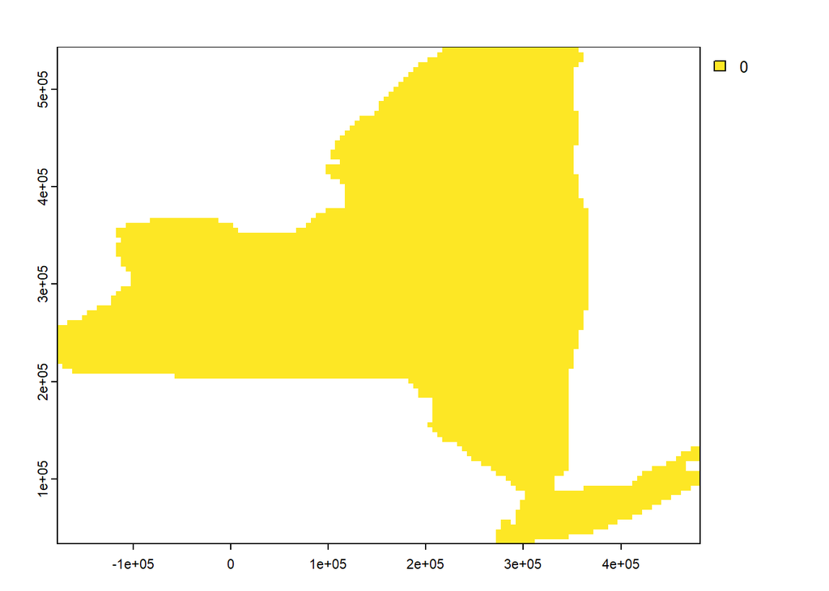

```r
# Prepare country template for rasterizing ----
resolution <- c(5000, 5000) # in metres

bbox_ny <-
  data_sf %>%
  select(siteID, geometry) %>%
  unique() %>%
  st_bbox()

country_border <-
  data_sf %>%
  select(siteID, geometry) %>%
  unique() %>%
  st_union() %>%
  vect()

# create masked template for rasterizing based on NY outlines
template <-
  rast(
    ext(bbox_ny$xmin, bbox_ny$xmax, bbox_ny$ymin, bbox_ny$ymax),
    resolution = resolution,
    crs = ny_crs)
values(template) <- 0
masked_template <- mask(template, country_border)

# check:
plot(masked_template)
```

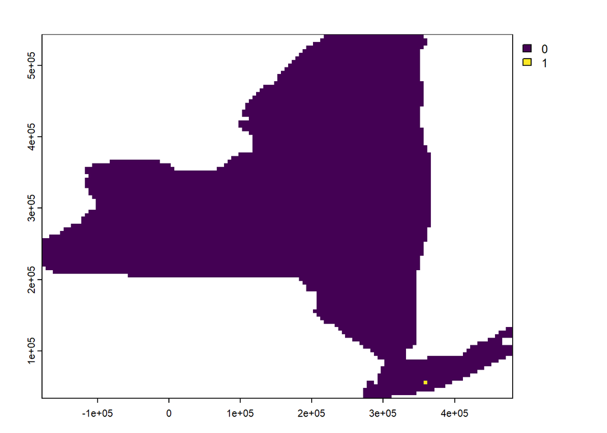

```r
# Prepare species data ----

unsampled_sites_expanded <-
  data_sf %>%
  filter(cell_sampling_repeats == 0) %>%
  distinct(siteID, geometry) %>%
  tidyr::expand_grid(samplingPeriodID = c(1,2)) %>%
  mutate(verbatimIdentification = NA)

# combine with sampled cells
data_sf_with_unsampled <-
  bind_rows(
    data_sf %>%
      filter(cell_sampling_repeats == 2 | !is.na(verbatimIdentification)),
    unsampled_sites_expanded
  )

# get filtered species list
species_list <-
  sci_name %>%
  pull(verbatimIdentification) %>%
  unique()

# rasterize ranges

raster_list <- replicate(2, list())
for (tp in seq_along(c(1,2))){

  raster_list[[tp]] <- list()

  data_tp_i <-
    data_sf_with_unsampled %>%
    filter(samplingPeriodID == tp)

  for (sp_name in species_list){

    this_data <-
      data_tp_i %>%
      filter(verbatimIdentification == sp_name & samplingPeriodID == tp) %>%
      st_as_sf() %>%
      st_transform(crs = ny_crs) %>%
      mutate(
        presence = 1)

  r <-
    rasterize(this_data,
              masked_template,
              field = "presence",
              update = TRUE)

  raster_list[[tp]][[sp_name]] <- r

  }
}

# example plot
plot(r)
```

```r
rm(list = setdiff(ls(),c("data_sf_path","tax_path","sp_data_path","sci_name","traits_merged", "pd", "IUCN_df", "range_geometries", "joincount_df", "raster_list")))
gc()
```

```
          used  (Mb) gc trigger   (Mb)  max used   (Mb)
Ncells 5195039 277.5   24750614 1321.9  30938267 1652.3
Vcells 8192303  62.6  113018644  862.3 141273305 1077.9
```

```r
# Calculate lacunarity across sub-lists
#----------------------------------------------------------#
# Function to run terra::focal() for multiple window-sizes -----
#----------------------------------------------------------#
apply_focal_multiple_w <- function(r, w_vec) {

  results <- lapply(w_vec, function(w) {
    f <- focal(r, w = w, fun = sum, na.policy="omit", na.rm=TRUE)

    # n_S_r = number of filled cells in the box (of size r)
    # Q_S_r = normalized frequency distribution of S for box size r

    box_masses_int <- as.integer(values(f, na.rm = T))
    max_value <- max(box_masses_int, na.rm = TRUE)

    # initialize empty vector (add +1 to enable indexing with 0 values)
    n_S_r <- integer(max_value + 1L)
    for (val in box_masses_int) {
      if (val >= 0 && val <= max_value) {
        n_S_r[val + 1L] <- n_S_r[val + 1L] + 1
      }
    }
    Q_S_r <- n_S_r / length(box_masses_int[!is.na(box_masses_int)])
    S_vals <- seq_along(Q_S_r) - 1
    Z_1 <- sum(S_vals * Q_S_r) #first moment = mean
    Z_2 <- sum((S_vals^2) * Q_S_r) # second moment = variance (mean of squared values)

    if (Z_1 == 0) {
      return(NA_real_)
    }
    lac <- Z_2 / (Z_1 * Z_1)

    return(lac)
  })


  names(results) <- paste0("w=", w_vec)
 r_name <- sp_name
  message(r_name, ": done")
  # lac_res <- data.frame(lac = do.call(rbind, results), w = w_vec, species = r_name)
  # return(lac_res)


  this_out <- dplyr::tibble(name = rep(r_name, length(results)),
                            r = w_vec, "ln(r)" = log(w_vec),
                            Lac = results %>% do.call(rbind,.) %>% .[,1], "ln(Lac)" = log(results %>% do.call(rbind,.) %>% .[,1]))
  return(this_out)
}
```

```r
#----------------------------------------------------------#
# Run focal function across multiple window-sizes -----
#----------------------------------------------------------#

w_vec <- c(3L, 5L, 9L, 17L, 33L) # window sizes

tictoc::tic()
res_list <- replicate(2, list())

for (tp_i in seq_along(raster_list)){
  res_list[[tp_i]] <- list()
  for(sp_i in seq_along(raster_list[[tp_i]])){

    sp_name <- names(raster_list[[tp_i]])[sp_i]
    r <- raster_list[[tp_i]][[sp_i]]
    test_res <- apply_focal_multiple_w(r, w_vec)

    # add species info
    test_res$samplingPeriodID <- tp_i
    test_res$verbatimIdentification <- sp_name


    res_list[[tp_i]][[sp_i]] <- test_res
  }
}
```

```
Picoides pubescens: done
```

```
Empidonax virescens: done
```

```
Geothlypis trichas: done
```

```
Dendroica fusca: done
```

```
Passerculus sandwichensis: done
```

```
Contopus virens: done
```

```
Spizella pusilla: done
```

```
Quiscalus quiscula: done
```

```
Dendroica magnolia: done
```

```
Sphyrapicus varius: done
```

```
Sayornis phoebe: done
```

```
Molothrus ater: done
```

```
Wilsonia citrina: done
```

```
Carpodacus purpureus: done
```

```
Myiarchus crinitus: done
```

```
Pheucticus ludovicianus: done
```

```
Coccyzus americanus: done
```

```
Dendroica petechia: done
```

```
Empidonax minimus: done
```

```
Dendroica pensylvanica: done
```

```
Hirundo rustica: done
```

```
Dumetella carolinensis: done
```

```
Setophaga ruticilla: done
```

```
Troglodytes aedon: done
```

```
Junco hyemalis: done
```

```
Sitta canadensis: done
```

```
Seiurus motacilla: done
```

```
Zenaida macroura: done
```

```
Chaetura pelagica: done
```

```
Oporornis philadelphia: done
```

```
Megaceryle alcyon: done
```

```
Sturnella magna: done
```

```
Riparia riparia: done
```

```
Spinus tristis: done
```

```
Poecile atricapillus: done
```

```
Melospiza melodia: done
```

```
Turdus migratorius: done
```

```
Dendroica caerulescens: done
```

```
Dendroica coronata: done
```

```
Icterus galbula: done
```

```
Spizella passerina: done
```

```
Melanerpes carolinus: done
```

```
Sialia sialis: done
```

```
Passerina cyanea: done
```

```
Falco sparverius: done
```

```
Certhia americana: done
```

```
Columba livia: done
```

```
Sitta carolinensis: done
```

```
Vireo olivaceus: done
```

```
Charadrius vociferus: done
```

```
Archilochus colubris: done
```

```
Seiurus aurocapilla: done
```

```
Dolichonyx oryzivorus: done
```

```
Pipilo erythrophthalmus: done
```

```
Dendroica virens: done
```

```
Meleagris gallopavo: done
```

```
Agelaius phoeniceus: done
```

```
Aix sponsa: done
```

```
Butorides virescens: done
```

```
Branta canadensis: done
```

```
Ardea herodias: done
```

```
Buteo platypterus: done
```

```
Cardinalis cardinalis: done
```

```
Bonasa umbellus: done
```

```
Buteo jamaicensis: done
```

```
Bombycilla cedrorum: done
```

```
Anas platyrhynchos: done
```

```
Baeolophus bicolor: done
```

```
Corvus brachyrhynchos: done
```

```
Cathartes aura: done
```

```
Toxostoma rufum: done
```

```
Piranga olivacea: done
```

```
Tyrannus tyrannus: done
```

```
Hylocichla mustelina: done
```

```
Catharus fuscescens: done
```

```
Vireo gilvus: done
```

```
Carpodacus mexicanus: done
```

```
Cyanocitta cristata: done
```

```
Colaptes auratus: done
```

```
Mimus polyglottos: done
```

```
Empidonax alnorum: done
```

```
Melospiza georgiana: done
```

```
Tachycineta bicolor: done
```

```
Dryocopus pileatus: done
```

```
Vermivora pinus: done
```

```
Progne subis: done
```

```
Empidonax traillii: done
```

```
Megascops asio: done
```

```
Icterus spurius: done
```

```
Picoides villosus: done
```

```
Accipiter cooperii: done
```

```
Vireo solitarius: done
```

```
Coccyzus erythropthalmus: done
```

```
Stelgidopteryx serripennis: done
```

```
Buteo lineatus: done
```

```
Accipiter gentilis: done
```

```
Seiurus noveboracensis: done
```

```
Catharus guttatus: done
```

```
Troglodytes troglodytes: done
```

```
Scolopax minor: done
```

```
Accipiter striatus: done
```

```
Actitis macularius: done
```

```
Anas rubripes: done
```

```
Gallinago delicata: done
```

```
Protonotaria citrea: done
```

```
Petrochelidon pyrrhonota: done
```

```
Fulica americana: done
```

```
Circus cyaneus: done
```

```
Melanerpes erythrocephalus: done
```

```
Thryothorus ludovicianus: done
```

```
Ammodramus henslowii: done
```

```
Bubo virginianus: done
```

```
Zonotrichia albicollis: done
```

```
Lophodytes cucullatus: done
```

```
Coccothraustes vespertinus: done
```

```
Haliaeetus leucocephalus: done
```

```
Wilsonia canadensis: done
```

```
Strix varia: done
```

```
Pooecetes gramineus: done
```

```
Spinus pinus: done
```

```
Bartramia longicauda: done
```

```
Porzana carolina: done
```

```
Mniotilta varia: done
```

```
Colinus virginianus: done
```

```
Polioptila caerulea: done
```

```
Ammodramus savannarum: done
```

```
Eremophila alpestris: done
```

```
Mergus merganser: done
```

```
Anas discors: done
```

```
Rallus limicola: done
```

```
Cistothorus palustris: done
```

```
Cistothorus platensis: done
```

```
Ixobrychus exilis: done
```

```
Vermivora ruficapilla: done
```

```
Vireo griseus: done
```

```
Vireo flavifrons: done
```

```
Regulus satrapa: done
```

```
Corvus corax: done
```

```
Chordeiles minor: done
```

```
Catharus ustulatus: done
```

```
Pandion haliaetus: done
```

```
Parula americana: done
```

```
Podilymbus podiceps: done
```

```
Aythya collaris: done
```

```
Oxyura jamaicensis: done
```

```
Botaurus lentiginosus: done
```

```
Gavia immer: done
```

```
Dendroica pinus: done
```

```
Spizella pallida: done
```

```
Dendroica cerulea: done
```

```
Gallinula chloropus: done
```

```
Spiza americana: done
```

```
Icteria virens: done
```

```
Vermivora chrysoptera: done
```

```
Larus argentatus: done
```

```
Sterna hirundo: done
```

```
Asio otus: done
```

```
Anas strepera: done
```

```
Anas americana: done
```

```
Anas crecca: done
```

```
Larus marinus: done
```

```
Hydropogne caspia: done
```

```
Dendroica discolor: done
```

```
Aegolius acadicus: done
```

```
Tyto alba: done
```

```
Oporornis formosus: done
```

```
Rallus elegans: done
```

```
Regulus calendula: done
```

```
Falco peregrinus: done
```

```
Larus delawarensis: done
```

```
Phalacrocorax auritus: done
```

```
Nycticorax nycticorax: done
```

```
Ardea alba: done
```

```
Aquila chrysaetos: done
```

```
Anas clypeata: done
```

```
Egretta thula: done
```

```
Caprimulgus vociferus: done
```

```
Asio flammeus: done
```

```
Dendroica dominica: done
```

```
Helmitheros vermivorum: done
```

```
Chlidonias niger: done
```

```
Loxia curvirostra: done
```

```
Anas acuta: done
```

```
Aythya americana: done
```

```
Aythya affinis: done
```

```
Lanius ludovicianus: done
```

```
Sturnella neglecta: done
```

```
Loxia leucoptera: done
```

```
Corvus ossifragus: done
```

```
Mergus serrator: done
```

```
Bucephala clangula: done
```

```
Aythya valisineria: done
```

```
Bubulcus ibis: done
```

```
Charadrius melodus: done
```

```
Contopus cooperi: done
```

```
Empidonax flaviventris: done
```

```
Vireo philadelphicus: done
```

```
Melospiza lincolnii: done
```

```
Euphagus carolinus: done
```

```
Poecile hudsonicus: done
```

```
Picoides arcticus: done
```

```
Picoides dorsalis: done
```

```
Dendroica castanea: done
```

```
Dendroica striata: done
```

```
Perisoreus canadensis: done
```

```
Vermivora peregrina: done
```

```
Falcipennis canadensis: done
```

```
Dendroica palmarum: done
```

```
Catharus bicknelli: done
```

```
Dendroica tigrina: done
```

```
Passerina caerulea: done
```

```
Wilsonia pusilla: done
```

```
Caprimulgus carolinensis: done
```

```
Ammodramus caudacutus: done
```

```
Rallus longirostris: done
```

```
Quiscalus major: done
```

```
Leucophaeus atricilla: done
```

```
Plegadis falcinellus: done
```

```
Tringa semipalmata: done
```

```
Haematopus palliatus: done
```

```
Nyctanassa violacea: done
```

```
Egretta caerulea: done
```

```
Ammodramus maritimus: done
```

```
Egretta tricolor: done
```

```
Piranga rubra: done
```

```
Anas platyrhynchos x A. rubripes: done
```

```
Rynchops niger: done
```

```
Sternula antillarum: done
```

```
Gelochelidon nilotica: done
```

```
Sterna forsteri: done
```

```
Vermivora chrysoptera x V. pinus: done
```

```
Sterna dougallii: done
```

```
Laterallus jamaicensis: done
```

```
Picoides pubescens: done
```

```
Empidonax virescens: done
```

```
Geothlypis trichas: done
```

```
Dendroica fusca: done
```

```
Passerculus sandwichensis: done
```

```
Contopus virens: done
```

```
Spizella pusilla: done
```

```
Quiscalus quiscula: done
```

```
Dendroica magnolia: done
```

```
Sphyrapicus varius: done
```

```
Sayornis phoebe: done
```

```
Molothrus ater: done
```

```
Wilsonia citrina: done
```

```
Carpodacus purpureus: done
```

```
Myiarchus crinitus: done
```

```
Pheucticus ludovicianus: done
```

```
Coccyzus americanus: done
```

```
Dendroica petechia: done
```

```
Empidonax minimus: done
```

```
Dendroica pensylvanica: done
```

```
Hirundo rustica: done
```

```
Dumetella carolinensis: done
```

```
Setophaga ruticilla: done
```

```
Troglodytes aedon: done
```

```
Junco hyemalis: done
```

```
Sitta canadensis: done
```

```
Seiurus motacilla: done
```

```
Zenaida macroura: done
```

```
Chaetura pelagica: done
```

```
Oporornis philadelphia: done
```

```
Megaceryle alcyon: done
```

```
Sturnella magna: done
```

```
Riparia riparia: done
```

```
Spinus tristis: done
```

```
Poecile atricapillus: done
```

```
Melospiza melodia: done
```

```
Turdus migratorius: done
```

```
Dendroica caerulescens: done
```

```
Dendroica coronata: done
```

```
Icterus galbula: done
```

```
Spizella passerina: done
```

```
Melanerpes carolinus: done
```

```
Sialia sialis: done
```

```
Passerina cyanea: done
```

```
Falco sparverius: done
```

```
Certhia americana: done
```

```
Columba livia: done
```

```
Sitta carolinensis: done
```

```
Vireo olivaceus: done
```

```
Charadrius vociferus: done
```

```
Archilochus colubris: done
```

```
Seiurus aurocapilla: done
```

```
Dolichonyx oryzivorus: done
```

```
Pipilo erythrophthalmus: done
```

```
Dendroica virens: done
```

```
Meleagris gallopavo: done
```

```
Agelaius phoeniceus: done
```

```
Aix sponsa: done
```

```
Butorides virescens: done
```

```
Branta canadensis: done
```

```
Ardea herodias: done
```

```
Buteo platypterus: done
```

```
Cardinalis cardinalis: done
```

```
Bonasa umbellus: done
```

```
Buteo jamaicensis: done
```

```
Bombycilla cedrorum: done
```

```
Anas platyrhynchos: done
```

```
Baeolophus bicolor: done
```

```
Corvus brachyrhynchos: done
```

```
Cathartes aura: done
```

```
Toxostoma rufum: done
```

```
Piranga olivacea: done
```

```
Tyrannus tyrannus: done
```

```
Hylocichla mustelina: done
```

```
Catharus fuscescens: done
```

```
Vireo gilvus: done
```

```
Carpodacus mexicanus: done
```

```
Cyanocitta cristata: done
```

```
Colaptes auratus: done
```

```
Mimus polyglottos: done
```

```
Empidonax alnorum: done
```

```
Melospiza georgiana: done
```

```
Tachycineta bicolor: done
```

```
Dryocopus pileatus: done
```

```
Vermivora pinus: done
```

```
Progne subis: done
```

```
Empidonax traillii: done
```

```
Megascops asio: done
```

```
Icterus spurius: done
```

```
Picoides villosus: done
```

```
Accipiter cooperii: done
```

```
Vireo solitarius: done
```

```
Coccyzus erythropthalmus: done
```

```
Stelgidopteryx serripennis: done
```

```
Buteo lineatus: done
```

```
Accipiter gentilis: done
```

```
Seiurus noveboracensis: done
```

```
Catharus guttatus: done
```

```
Troglodytes troglodytes: done
```

```
Scolopax minor: done
```

```
Accipiter striatus: done
```

```
Actitis macularius: done
```

```
Anas rubripes: done
```

```
Gallinago delicata: done
```

```
Protonotaria citrea: done
```

```
Petrochelidon pyrrhonota: done
```

```
Fulica americana: done
```

```
Circus cyaneus: done
```

```
Melanerpes erythrocephalus: done
```

```
Thryothorus ludovicianus: done
```

```
Ammodramus henslowii: done
```

```
Bubo virginianus: done
```

```
Zonotrichia albicollis: done
```

```
Lophodytes cucullatus: done
```

```
Coccothraustes vespertinus: done
```

```
Haliaeetus leucocephalus: done
```

```
Wilsonia canadensis: done
```

```
Strix varia: done
```

```
Pooecetes gramineus: done
```

```
Spinus pinus: done
```

```
Bartramia longicauda: done
```

```
Porzana carolina: done
```

```
Mniotilta varia: done
```

```
Colinus virginianus: done
```

```
Polioptila caerulea: done
```

```
Ammodramus savannarum: done
```

```
Eremophila alpestris: done
```

```
Mergus merganser: done
```

```
Anas discors: done
```

```
Rallus limicola: done
```

```
Cistothorus palustris: done
```

```
Cistothorus platensis: done
```

```
Ixobrychus exilis: done
```

```
Vermivora ruficapilla: done
```

```
Vireo griseus: done
```

```
Vireo flavifrons: done
```

```
Regulus satrapa: done
```

```
Corvus corax: done
```

```
Chordeiles minor: done
```

```
Catharus ustulatus: done
```

```
Pandion haliaetus: done
```

```
Parula americana: done
```

```
Podilymbus podiceps: done
```

```
Aythya collaris: done
```

```
Oxyura jamaicensis: done
```

```
Botaurus lentiginosus: done
```

```
Gavia immer: done
```

```
Dendroica pinus: done
```

```
Spizella pallida: done
```

```
Dendroica cerulea: done
```

```
Gallinula chloropus: done
```

```
Spiza americana: done
```

```
Icteria virens: done
```

```
Vermivora chrysoptera: done
```

```
Larus argentatus: done
```

```
Sterna hirundo: done
```

```
Asio otus: done
```

```
Anas strepera: done
```

```
Anas americana: done
```

```
Anas crecca: done
```

```
Larus marinus: done
```

```
Hydropogne caspia: done
```

```
Dendroica discolor: done
```

```
Aegolius acadicus: done
```

```
Tyto alba: done
```

```
Oporornis formosus: done
```

```
Rallus elegans: done
```

```
Regulus calendula: done
```

```
Falco peregrinus: done
```

```
Larus delawarensis: done
```

```
Phalacrocorax auritus: done
```

```
Nycticorax nycticorax: done
```

```
Ardea alba: done
```

```
Aquila chrysaetos: done
```

```
Anas clypeata: done
```

```
Egretta thula: done
```

```
Caprimulgus vociferus: done
```

```
Asio flammeus: done
```

```
Dendroica dominica: done
```

```
Helmitheros vermivorum: done
```

```
Chlidonias niger: done
```

```
Loxia curvirostra: done
```

```
Anas acuta: done
```

```
Aythya americana: done
```

```
Aythya affinis: done
```

```
Lanius ludovicianus: done
```

```
Sturnella neglecta: done
```

```
Loxia leucoptera: done
```

```
Corvus ossifragus: done
```

```
Mergus serrator: done
```

```
Bucephala clangula: done
```

```
Aythya valisineria: done
```

```
Bubulcus ibis: done
```

```
Charadrius melodus: done
```

```
Contopus cooperi: done
```

```
Empidonax flaviventris: done
```

```
Vireo philadelphicus: done
```

```
Melospiza lincolnii: done
```

```
Euphagus carolinus: done
```

```
Poecile hudsonicus: done
```

```
Picoides arcticus: done
```

```
Picoides dorsalis: done
```

```
Dendroica castanea: done
```

```
Dendroica striata: done
```

```
Perisoreus canadensis: done
```

```
Vermivora peregrina: done
```

```
Falcipennis canadensis: done
```

```
Dendroica palmarum: done
```

```
Catharus bicknelli: done
```

```
Dendroica tigrina: done
```

```
Passerina caerulea: done
```

```
Wilsonia pusilla: done
```

```
Caprimulgus carolinensis: done
```

```
Ammodramus caudacutus: done
```

```
Rallus longirostris: done
```

```
Quiscalus major: done
```

```
Leucophaeus atricilla: done
```

```
Plegadis falcinellus: done
```

```
Tringa semipalmata: done
```

```
Haematopus palliatus: done
```

```
Nyctanassa violacea: done
```

```
Egretta caerulea: done
```

```
Ammodramus maritimus: done
```

```
Egretta tricolor: done
```

```
Piranga rubra: done
```

```
Anas platyrhynchos x A. rubripes: done
```

```
Rynchops niger: done
```

```
Sternula antillarum: done
```

```
Gelochelidon nilotica: done
```

```
Sterna forsteri: done
```

```
Vermivora chrysoptera x V. pinus: done
```

```
Sterna dougallii: done
```

```
Laterallus jamaicensis: done
```

```r
tictoc::toc() # 96.32 sec elapsed
```

```
23.62 sec elapsed
```

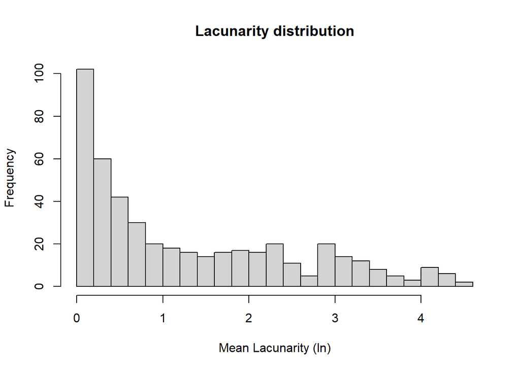

```r
df_res1 <- do.call(rbind, res_list[[1]])
df_res2 <- do.call(rbind, res_list[[2]])

lac_results <-
  rbind(df_res1, df_res2) %>%
  select(-name) %>%
  as.data.frame()

names(lac_results) <- c("r", "ln(r)", "lac", "ln(lac)", "samplingPeriodID", "verbatimIdentification")


# Calculate mean across increasing window sizes
mean_lac <- lac_results %>%
  ungroup() %>%
  group_by(samplingPeriodID, verbatimIdentification) %>%
  summarize(mean_lnLac = mean(`ln(lac)`, na.rm = TRUE), .groups = "keep")


hist(mean_lac$mean_lnLac, breaks = 30,
     main = "Lacunarity distribution",
     xlab = "Mean Lacunarity (ln)")
```

```r
rm(list = setdiff(ls(),c("data_sf_path","tax_path","sp_data_path","sci_name","traits_merged", "pd", "IUCN_df", "range_geometries", "joincount_df", "mean_lac")))
gc()
```

```
          used  (Mb) gc trigger   (Mb)  max used   (Mb)
Ncells 5299359 283.1   19800492 1057.5  30938267 1652.3
Vcells 8219171  62.8   90414916  689.9 141273305 1077.9
```

### Global range size

We again use the BirdLife range polygons [6], which can be downloaded from [here](http://datazone.birdlife.org/species/requestdis). We use the Mollweide projection to calculate the global range size in km². The BirdLife shapefile is in WGS84, so we transform it to Mollweide before calculating the area.

```r
# planar CRS
Mollweide_CRS <-
'PROJCS["ProjWiz_Custom_Mollweide",
 GEOGCS["GCS_WGS_1984",
  DATUM["D_WGS_1984",
   SPHEROID["WGS_1984",6378137.0,298.257223563]],
  PRIMEM["Greenwich",0.0],
  UNIT["Degree",0.0174532925199433]],
 PROJECTION["Mollweide"],
 PARAMETER["False_Easting",0.0],
 PARAMETER["False_Northing",0.0],
 PARAMETER["Central_Meridian",0],
 UNIT["Meter",1.0]]'

sf_use_s2(FALSE)

# Taxonomic match table
Tax <-
  sci_name # Taxa

# Global ranges
tictoc::tic()
BirdLife_split <-
  st_read(here("Data/input/shp_global/BirdLife.shp"), quiet = TRUE)%>%
  filter(sci_name %in% c(Tax$scientificName)) %>%
  st_transform(crs = Mollweide_CRS)%>%
  group_by(sci_name) %>%
  st_make_valid() %>% # takes a while...
  group_by(sci_name) %>%
  group_split()


# loop through list and sum up the combined range areas for each species
range_size_df <-
  map_dfr(BirdLife_split, function(this_species){

    message(paste0(unique(this_species$sci_name), "... done!"))

    this_species %>%
      group_by(sci_name) %>%
      summarise(.groups = "keep") %>%
      # Convert to km²
      group_by(sci_name) %>%
      mutate(GlobRangeSize_km2 = as.numeric(st_area(.))/ 1e6) %>%
      st_drop_geometry()%>%
      rename(scientificName = sci_name)


    })
```

```
Accipiter cooperii... done!
```

```
Accipiter gentilis... done!
```

```
Accipiter striatus... done!
```

```
Actitis macularius... done!
```

```
Aegolius acadicus... done!
```

```
Agelaius phoeniceus... done!
```

```
Aix sponsa... done!
```

```
Ammodramus savannarum... done!
```

```
Ammospiza caudacuta... done!
```

```
Ammospiza maritima... done!
```

```
Anas acuta... done!
```

```
Anas crecca... done!
```

```
Anas platyrhynchos... done!
```

```
Anas rubripes... done!
```

```
Antrostomus carolinensis... done!
```

```
Antrostomus vociferus... done!
```

```
Aquila chrysaetos... done!
```

```
Archilochus colubris... done!
```

```
Ardea alba... done!
```

```
Ardea herodias... done!
```

```
Asio flammeus... done!
```

```
Asio otus... done!
```

```
Aythya affinis... done!
```

```
Aythya americana... done!
```

```
Aythya collaris... done!
```

```
Aythya valisineria... done!
```

```
Baeolophus bicolor... done!
```

```
Bartramia longicauda... done!
```

```
Bombycilla cedrorum... done!
```

```
Bonasa umbellus... done!
```

```
Botaurus lentiginosus... done!
```

```
Branta canadensis... done!
```

```
Bubo virginianus... done!
```

```
Bubulcus ibis... done!
```

```
Bucephala clangula... done!
```

```
Buteo jamaicensis... done!
```

```
Buteo lineatus... done!
```

```
Buteo platypterus... done!
```

```
Butorides striata... done!
```

```
Canachites canadensis... done!
```

```
Cardellina canadensis... done!
```

```
Cardellina pusilla... done!
```

```
Cardinalis cardinalis... done!
```

```
Cathartes aura... done!
```

```
Catharus bicknelli... done!
```

```
Catharus fuscescens... done!
```

```
Catharus guttatus... done!
```

```
Catharus ustulatus... done!
```

```
Certhia americana... done!
```

```
Chaetura pelagica... done!
```

```
Charadrius melodus... done!
```

```
Charadrius vociferus... done!
```

```
Chlidonias niger... done!
```

```
Chordeiles minor... done!
```

```
Circus cyaneus... done!
```

```
Cistothorus palustris... done!
```

```
Cistothorus platensis... done!
```

```
Coccyzus americanus... done!
```

```
Coccyzus erythropthalmus... done!
```

```
Colaptes auratus... done!
```

```
Colinus virginianus... done!
```

```
Columba livia... done!
```

```
Contopus cooperi... done!
```

```
Contopus virens... done!
```

```
Corthylio calendula... done!
```

```
Corvus brachyrhynchos... done!
```

```
Corvus corax... done!
```

```
Corvus ossifragus... done!
```

```
Cyanocitta cristata... done!
```

```
Dolichonyx oryzivorus... done!
```

```
Dryobates pubescens... done!
```

```
Dumetella carolinensis... done!
```

```
Egretta caerulea... done!
```

```
Egretta thula... done!
```

```
Egretta tricolor... done!
```

```
Empidonax alnorum... done!
```

```
Empidonax flaviventris... done!
```

```
Empidonax minimus... done!
```

```
Empidonax traillii... done!
```

```
Empidonax virescens... done!
```

```
Eremophila alpestris... done!
```

```
Euphagus carolinus... done!
```

```
Falco peregrinus... done!
```

```
Falco sparverius... done!
```

```
Fulica americana... done!
```

```
Gallinago delicata... done!
```

```
Gallinula chloropus... done!
```

```
Gavia immer... done!
```

```
Gelochelidon nilotica... done!
```

```
Geothlypis formosa... done!
```

```
Geothlypis philadelphia... done!
```

```
Geothlypis trichas... done!
```

```
Haematopus palliatus... done!
```

```
Haemorhous mexicanus... done!
```

```
Haemorhous purpureus... done!
```

```
Haliaeetus leucocephalus... done!
```

```
Helmitheros vermivorum... done!
```

```
Hesperiphona vespertina... done!
```

```
Hirundo rustica... done!
```

```
Hydroprogne caspia... done!
```

```
Hylatomus pileatus... done!
```

```
Hylocichla mustelina... done!
```

```
Icteria virens... done!
```

```
Icterus galbula... done!
```

```
Icterus spurius... done!
```

```
Ixobrychus exilis... done!
```

```
Junco hyemalis... done!
```

```
Lanius ludovicianus... done!
```

```
Larus argentatus... done!
```

```
Larus atricilla... done!
```

```
Larus delawarensis... done!
```

```
Larus marinus... done!
```

```
Laterallus jamaicensis... done!
```

```
Leiothlypis peregrina... done!
```

```
Leiothlypis ruficapilla... done!
```

```
Leuconotopicus villosus... done!
```

```
Lophodytes cucullatus... done!
```

```
Loxia curvirostra... done!
```

```
Loxia leucoptera... done!
```

```
Mareca americana... done!
```

```
Mareca strepera... done!
```

```
Megaceryle alcyon... done!
```

```
Megascops asio... done!
```

```
Melanerpes carolinus... done!
```

```
Melanerpes erythrocephalus... done!
```

```
Meleagris gallopavo... done!
```

```
Melospiza georgiana... done!
```

```
Melospiza lincolnii... done!
```

```
Melospiza melodia... done!
```

```
Mergus merganser... done!
```

```
Mergus serrator... done!
```

```
Mimus polyglottos... done!
```

```
Mniotilta varia... done!
```

```
Molothrus ater... done!
```

```
Myiarchus crinitus... done!
```

```
Nannopterum auritus... done!
```

```
Nyctanassa violacea... done!
```

```
Nycticorax nycticorax... done!
```

```
Oxyura jamaicensis... done!
```

```
Pandion haliaetus... done!
```

```
Parkesia motacilla... done!
```

```
Parkesia noveboracensis... done!
```

```
Passerculus henslowii... done!
```

```
Passerculus sandwichensis... done!
```

```
Passerina caerulea... done!
```

```
Passerina cyanea... done!
```

```
Perisoreus canadensis... done!
```

```
Petrochelidon pyrrhonota... done!
```

```
Pheucticus ludovicianus... done!
```

```
Picoides arcticus... done!
```

```
Picoides tridactylus... done!
```

```
Pipilo erythrophthalmus... done!
```

```
Piranga olivacea... done!
```

```
Piranga rubra... done!
```

```
Plegadis falcinellus... done!
```

```
Podilymbus podiceps... done!
```

```
Poecile atricapillus... done!
```

```
Poecile hudsonicus... done!
```

```
Polioptila caerulea... done!
```

```
Pooecetes gramineus... done!
```

```
Porzana carolina... done!
```

```
Progne subis... done!
```

```
Protonotaria citrea... done!
```

```
Quiscalus major... done!
```

```
Quiscalus quiscula... done!
```

```
Rallus elegans... done!
```

```
Rallus limicola... done!
```

```
Rallus longirostris... done!
```

```
Regulus satrapa... done!
```

```
Riparia riparia... done!
```

```
Rynchops niger... done!
```

```
Sayornis phoebe... done!
```

```
Scolopax minor... done!
```

```
Seiurus aurocapilla... done!
```

```
Setophaga americana... done!
```

```
Setophaga caerulescens... done!
```

```
Setophaga castanea... done!
```

```
Setophaga cerulea... done!
```

```
Setophaga citrina... done!
```

```
Setophaga coronata... done!
```

```
Setophaga discolor... done!
```

```
Setophaga dominica... done!
```

```
Setophaga fusca... done!
```

```
Setophaga magnolia... done!
```

```
Setophaga palmarum... done!
```

```
Setophaga pensylvanica... done!
```

```
Setophaga petechia... done!
```

```
Setophaga pinus... done!
```

```
Setophaga ruticilla... done!
```

```
Setophaga striata... done!
```

```
Setophaga tigrina... done!
```

```
Setophaga virens... done!
```

```
Sialia sialis... done!
```

```
Sitta canadensis... done!
```

```
Sitta carolinensis... done!
```

```
Spatula clypeata... done!
```

```
Spatula discors... done!
```

```
Sphyrapicus varius... done!
```

```
Spinus pinus... done!
```

```
Spinus tristis... done!
```

```
Spiza americana... done!
```

```
Spizella pallida... done!
```

```
Spizella passerina... done!
```

```
Spizella pusilla... done!
```

```
Stelgidopteryx serripennis... done!
```

```
Sterna dougallii... done!
```

```
Sterna forsteri... done!
```

```
Sterna hirundo... done!
```

```
Sternula antillarum... done!
```

```
Strix varia... done!
```

```
Sturnella magna... done!
```

```
Sturnella neglecta... done!
```

```
Tachycineta bicolor... done!
```

```
Thryothorus ludovicianus... done!
```

```
Toxostoma rufum... done!
```

```
Tringa semipalmata... done!
```

```
Troglodytes aedon... done!
```

```
Troglodytes troglodytes... done!
```

```
Turdus migratorius... done!
```

```
Tyrannus tyrannus... done!
```

```
Tyto alba... done!
```

```
Vermivora chrysoptera... done!
```

```
Vermivora cyanoptera... done!
```

```
Vireo flavifrons... done!
```

```
Vireo gilvus... done!
```

```
Vireo griseus... done!
```

```
Vireo olivaceus... done!
```

```
Vireo philadelphicus... done!
```

```
Vireo solitarius... done!
```

```
Zenaida macroura... done!
```

```
Zonotrichia albicollis... done!
```

```r
tictoc::toc()
```

```
549.33 sec elapsed
```

```r
# Merge with verbatimIdentification
range_size_df2 <-
  range_size_df %>%
  right_join(Tax, by = "scientificName") %>%
  distinct(scientificName, verbatimIdentification, .keep_all = TRUE)

# checks
colSums(is.na(range_size_df2))
```

```
        scientificName      GlobRangeSize_km2 verbatimIdentification
                     0                      2                      0
```

```r
range(range_size_df2$GlobRangeSize_km2, na.rm=TRUE)
```

```
[1]    38728.84 75222636.54
```

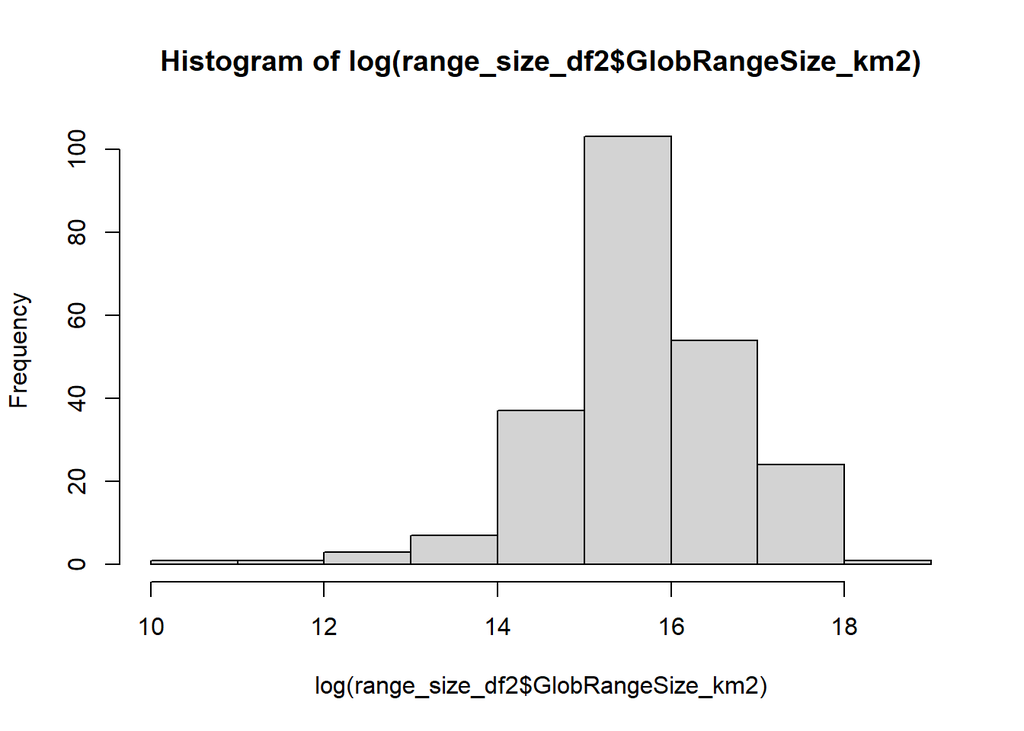

```r
hist(log(range_size_df2$GlobRangeSize_km2))
```

```r
rm(list = setdiff(ls(),c("data_sf_path","tax_path","sp_data_path","sci_name","traits_merged", "pd", "IUCN_df", "range_geometries", "joincount_df", "mean_lac", "range_size_df2")))
gc()
```

```
          used  (Mb) gc trigger   (Mb)  max used   (Mb)
Ncells 5122475 273.6   15840394  846.0  30938267 1652.3
Vcells 8164532  62.3  274541331 2094.6 428947440 3272.7
```

## Merge Predictors together

```r
# Set 1: External data
predictors_1 <-
  full_join(range_size_df2, traits_merged) %>%
  full_join(IUCN_df %>% mutate(code = as.factor(code)) %>% rename("IUCN" = "code")) %>%
  full_join(pd) %>%
  distinct(verbatimIdentification, .keep_all = TRUE)
colSums(is.na(predictors_1))
```

```
        scientificName      GlobRangeSize_km2 verbatimIdentification
                     0                      2                      0
                  Mass                Habitat              Migration
                     3                      3                      3
     Primary.Lifestyle                   IUCN                     pd
                     3                      2                      3
```

```r
glimpse(predictors_1)
```

```
Rows: 233
Columns: 9
Groups: scientificName [233]
$ scientificName         <chr> "Accipiter cooperii", "Accipiter gentilis", "Ac…
$ GlobRangeSize_km2      <dbl> 8402847.43, 31714948.46, 16393557.31, 13610945.…
$ verbatimIdentification <chr> "Accipiter cooperii", "Accipiter gentilis", "Ac…
$ Mass                   <dbl> 429.67, 866.04, 130.59, 40.40, 100.69, 50.78, 6…
$ Habitat                <fct> Woodland, Forest, Forest, Wetland, Forest, Wetl…
$ Migration              <fct> 3, 2, 3, 3, 3, 3, 1, 2, 3, 2, 3, 2, 2, 2, 3, 3,…
$ Primary.Lifestyle      <fct> Aerial, Generalist, Aerial, Terrestrial, Insess…
$ IUCN                   <fct> LC, LC, LC, LC, LC, LC, LC, LC, EN, LC, LC, LC,…
$ pd                     <dbl> 7.899108, 6.994202, 5.769648, 27.170491, 12.953…
```

```r
# Set 2: Calculated from atlas

big_table <-
  readRDS(here("Demo_NewYork/Data/output/A_Big_table_ny.rds"))

predictors_2 <-
  full_join(big_table, joincount_df) %>%
  full_join(range_geometries) %>%
  full_join(mean_lac) %>%
  distinct(samplingPeriodID, verbatimIdentification, .keep_all = TRUE)
```

[output not shown]

```r
colSums(is.na(predictors_2))
```

```
             datasetID verbatimIdentification       samplingPeriodID
                     0                      0                      0
       Total_area_samp           Total_Ncells      Total_Ncells_samp
                     0                      0                      0
                   AOO             occ_Ncells         rel_occ_Ncells
                     0                      0                      0
               rel_AOO         Jaccard_dissim                      a
                     0                      0                      0
                     b                      c                      d
                     0                      0                      0
               D_AOO_a              time_span              startYear
                     0                      0                      0
               endYear                n_years               log_R2_1
                     0                      0                      0
     log_R2_1_per_year             presence_n    joincount_statistic
                     0                      0                      0
 joincount_expectation        joincount_p_val        joincount_delta
                     0                     11                      0
              circNorm minDist_toBorder_centr             mean_lnLac
                     0                      0                      0
```

```r
glimpse(predictors_2)
```

```
Rows: 466
Columns: 30
$ datasetID              <dbl> 6, 6, 6, 6, 6, 6, 6, 6, 6, 6, 6, 6, 6, 6, 6, 6,…
$ verbatimIdentification <chr> "Accipiter cooperii", "Accipiter gentilis", "Ac…
$ samplingPeriodID       <dbl> 1, 1, 1, 1, 1, 1, 1, 1, 1, 1, 1, 1, 1, 1, 1, 1,…
$ Total_area_samp        <dbl> 126878.5, 126878.5, 126878.5, 126878.5, 126878.…
$ Total_Ncells           <dbl> 5335, 5335, 5335, 5335, 5335, 5335, 5335, 5335,…
$ Total_Ncells_samp      <dbl> 5319, 5319, 5319, 5319, 5319, 5319, 5319, 5319,…
$ AOO                    <dbl> 13645.261, 10967.382, 21187.304, 48157.370, 321…
$ occ_Ncells             <dbl> 550, 444, 859, 2021, 129, 5059, 1923, 72, 348, …
$ rel_occ_Ncells         <dbl> 0.103, 0.083, 0.161, 0.380, 0.024, 0.951, 0.362…
$ rel_AOO                <dbl> 0.108, 0.086, 0.167, 0.380, 0.025, 0.954, 0.370…
$ Jaccard_dissim         <dbl> 0.881, 0.904, 0.849, 0.697, 0.950, 0.068, 0.623…
$ a                      <dbl> 202, 70, 301, 881, 13, 4837, 1288, 48, 18, 27, …
$ b                      <dbl> 1152, 285, 1138, 888, 133, 133, 1496, 13, 52, 9…
```

[output cut: 17 more lines]

#### Modify predictors for modeling

```r
# Merge together
data_final <-
  full_join(predictors_2, predictors_1) %>%
  filter(samplingPeriodID == 1) %>%
  mutate(
    across(
      where(is.character) &
        !matches("verbatimIdentification") &
        !matches("scientificName"),
      as.factor)) %>%
  mutate(
    across(
      c("Habitat", "IUCN", "Migration", "Primary.Lifestyle"),
      as.factor)) %>%
  distinct(verbatimIdentification, .keep_all = TRUE) %>%
  ungroup() %>%
  mutate(
    Habitat_5 =
      as.factor(
        case_when(
          Habitat %in% c("Grassland", "Shrubland",
                         "Desert", "Rock") ~ "open",
          Habitat %in% c("Woodland", "Forest") ~ "closed",
          Habitat %in% c("Coastal", "Marine") ~ "marine",
          Habitat %in% c("Wetland", "Riverine") ~ "freshwater",
          Habitat == "Human Modified" ~ "human",
          .default = NA_character_)
        )
    ) %>%
  mutate(
    Generalism =
      as.factor(
        case_when(
          Primary.Lifestyle == "Generalist" ~ 1,
          .default = 0)
        )
    ) %>%
  mutate(
    Threatened =
      as.factor(
        case_when(
          IUCN %in% c("LC") ~ 0,
          is.na(IUCN) ~ NA,
          .default = 1)
        )
    ) %>%
  select(
    verbatimIdentification, scientificName,
    log_R2_1, log_R2_1_per_year, Jaccard_dissim,
    D_AOO_a, AOO, joincount_delta, mean_lnLac,
    circNorm, minDist_toBorder_centr,
    GlobRangeSize_km2, Mass, Migration,
    pd, Habitat_5, Generalism, Threatened
  )
data_final %>%
  skimr::skim()
```

Data summary

| Name | Piped data |
| --- | --- |
| Number of rows | 233 |
| Number of columns | 18 |
| _______________________ |  |
| Column type frequency: |  |
| character | 2 |
| factor | 4 |
| numeric | 12 |
| ________________________ |  |
| Group variables | None |

**Variable type: character**

| skim_variable | n_missing | complete_rate | min | max | empty | n_unique | whitespace |
| --- | --- | --- | --- | --- | --- | --- | --- |
| verbatimIdentification | 0 | 1 | 9 | 32 | 0 | 233 | 0 |
| scientificName | 0 | 1 | 9 | 39 | 0 | 233 | 0 |

**Variable type: factor**

| skim_variable | n_missing | complete_rate | ordered | n_unique | top_counts |
| --- | --- | --- | --- | --- | --- |
| Migration | 3 | 0.99 | FALSE | 3 | 3: 143, 2: 47, 1: 40, NA: 0 |
| Habitat_5 | 3 | 0.99 | FALSE | 5 | clo: 108, fre: 55, ope: 41, mar: 17 |
| Generalism | 0 | 1.00 | FALSE | 2 | 0: 202, 1: 31 |
| Threatened | 2 | 0.99 | FALSE | 2 | 0: 212, 1: 19 |

**Variable type: numeric**

| skim_variable | n_missing | complete_rate | mean | sd | p0 | p25 | p50 | p75 | p100 | hist |
| --- | --- | --- | --- | --- | --- | --- | --- | --- | --- | --- |
| log_R2_1 | 0 | 1.00 | 0.06 | 0.66 | -1.79 | -0.15 | 0.01 | 0.24 | 3.75 | ▁▇▁▁▁ |
| log_R2_1_per_year | 0 | 1.00 | 0.01 | 0.13 | -0.36 | -0.03 | 0.00 | 0.05 | 0.75 | ▁▇▁▁▁ |
| Jaccard_dissim | 0 | 1.00 | 0.61 | 0.28 | 0.00 | 0.43 | 0.68 | 0.84 | 1.00 | ▃▃▃▇▇ |
| D_AOO_a | 0 | 1.00 | 1.31 | 0.55 | 0.00 | 0.90 | 1.41 | 1.81 | 1.98 | ▂▂▃▃▇ |
| AOO | 0 | 1.00 | 36317.49 | 41373.36 | 4.98 | 1117.66 | 14775.02 | 67379.24 | 124025.31 | ▇▂▁▂▂ |
| joincount_delta | 0 | 1.00 | 0.70 | 0.51 | 0.00 | 0.30 | 0.59 | 1.08 | 2.16 | ▇▆▅▂▁ |
| mean_lnLac | 0 | 1.00 | 1.32 | 1.23 | 0.06 | 0.25 | 0.81 | 2.23 | 4.51 | ▇▂▂▂▁ |
| circNorm | 0 | 1.00 | 174.74 | 173.24 | 1.27 | 32.02 | 116.16 | 284.30 | 733.85 | ▇▂▂▁▁ |
| minDist_toBorder_centr | 0 | 1.00 | 35094.08 | 17486.26 | 1178.59 | 24849.69 | 35580.49 | 44151.44 | 93733.18 | ▅▇▆▂▁ |
| GlobRangeSize_km2 | 2 | 0.99 | 10454413.81 | 12006642.63 | 38728.84 | 3522641.41 | 6322724.06 | 11841957.85 | 75222636.54 | ▇▁▁▁▁ |
| Mass | 3 | 0.99 | 324.87 | 747.25 | 3.09 | 14.40 | 47.18 | 334.61 | 5791.37 | ▇▁▁▁▁ |
| pd | 3 | 0.99 | 7.55 | 6.26 | 1.47 | 3.84 | 5.65 | 8.97 | 51.14 | ▇▁▁▁▁ |

```r
write.csv(data_final, here::here("Demo_NewYork/Data/output/data_final_ny.csv"))
```

## References

[1] Tobias, J. A., Sheard, C., Pigot, A. L., Devenish, A. J., Yang, J., Sayol, F., Neate-Clegg, M. H., Alioravainen, N., Weeks, T. L., Barber, R. A., & others. (2022). AVONET: morphological, ecological and geographical data for all birds. Ecology Letters, 25(3), 581–597.

[2] Jetz, W., Thomas, G. H., Joy, J. B., Hartmann, K., & Mooers, A. O. (2012). The global diversity of birds in space and time. Nature, 491(7424), 444–448.

[3] Rubolini, D., Liker, A., Garamszegi, L. Z., Møller, A. P., & Saino, N. (2015). Using the BirdTree.org website to obtain robust phylogenies for avian comparative studies: A primer. Current Zoology, 61(6), 959–965. https://doi.org/10.1093/czoolo/61.6.959

[4] IUCN (2025). The IUCN Red List of Threatened Species. Version 2025-1. https://www.iucnredlist.org. Accessed 14 June 2025.

[5] Soria, C. D., Ortega-Solís, G. R., Wölke, F. J. R., Barták, V., Tschernosterová, K., Bejček, V., Herrando, S., Mikuláš, I., Šťastný, K., Ueta, M., Voříšek, P., & Keil, P. (Preprint, 2025). Spatial autocorrelation of species diversity and distributions in time and across spatial scales. https://doi.org/10.1101/2025.06.13.659470

[6] BirdLife International & Handbook of the Birds of the World. (2024). Bird species distribution maps of the world (Version 9.0) [Dataset]. http://datazone.birdlife.org/species/requestdis